# Human Activity Recognition Predictor

Guilherme Junqueira

September 17, 2016

# Summary

The aim of this project is to build a model that try to classify the exercises performed by six young adults in five different ways: exactly according to the specification (Class A), throwing the elbows to the front (Class B), lifting the dumbbell only halfway (Class C), lowering the dumbbell only halfway (Class D) and throwing the hips to the front (Class E).

We trained a random forest model and achieved the accuracy of 99.41% with a 5-fold repeated cross validation with 3 runs in the training data.

# Pre processing

Firstly, we get the files online. During the initial exploration of the data, it was noted that some columns have the string ‘#DIV/0!’ which probably indicates a division by zero error. This leads to some numeric columns being mistakenly treated as character columns, so we remove this string and the double quotes from the file.

```r
file_train <- "./train_file.csv"
file_test  <- "./test_file.csv"

# Only download it if we don't have it.
if( !file.exists(file_train) ){
    # gets the filse online
    u1 <- url("https://d396qusza40orc.cloudfront.net/predmachlearn/pml-training.csv")
    u2 <- url("https://d396qusza40orc.cloudfront.net/predmachlearn/pml-testing.csv")
    f1 <- readLines(u1)
    f2 <- readLines(u2)
    close(u1)
    close(u2)

    # removes double quotes and the string #DIV/0!
    c1 <- gsub( "(\")|(#DIV/0!)", "", f1)
    c2 <- gsub( "(\")|(#DIV/0!)", "", f2)

    # save it to disk
    writeLines(c1, file_train)
    writeLines(c2, file_test)
}

# Load to data frame
data_train <- read.csv(file_train, na.strings = c("NA") )
data_test  <- read.csv(file_test, na.strings = c("NA") )

# Remove files' names
rm(file_test, file_train)

dim(data_train)
```

```
## [1] 19622   160
```

As we can see above, there are 19622 rows and 160 columns in the training data set. Some of the rows may not contribute to the model either because they are not related to the sensors used or because they have a high proportion (>90%) of missing values.

Those columns are removed in the section below and the datasets are reduced to 53 columns with better quality data.

```r
# Removing variables unrelated to the sensors
data_train <- subset(
    data_train,
    select = -c(X, new_window, num_window,
                raw_timestamp_part_1, raw_timestamp_part_2,
                user_name, cvtd_timestamp)
)
data_test <- subset(
    data_test,
    select = -c(X, new_window, num_window,
                raw_timestamp_part_1, raw_timestamp_part_2,
                user_name, cvtd_timestamp)
)

# Removing columns with more than 90% missing values
mostly_data <- apply(!is.na(data_train), 2, sum) > (0.90 * nrow(data_train))

data_train <- data_train[, mostly_data]
data_test  <- data_test[, mostly_data]

# Removing temporary objects
rm(mostly_data)

dim(data_train)
```

```
## [1] 19622    53
```

# Model selection

Now that we have better data, we will train and evaluate our model. In the same fashion of the [original work](http://groupware.les.inf.puc-rio.br/public/papers/2013.Velloso.QAR-WLE.pdf), we chose a random forest predictor because of the inherent noise present in the data and the likely feature selection provided by the algorithm.

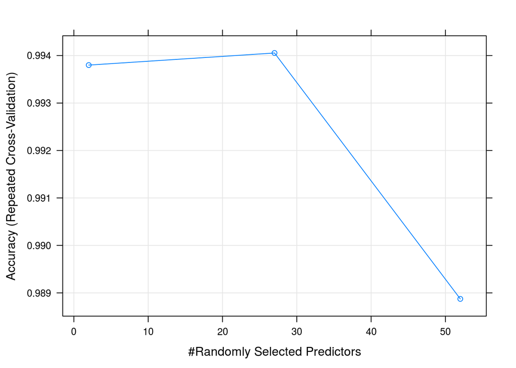

```r
# For reproducibility reasons
set.seed(2016)
k_fold       <- 5
num_repeats  <- 3
seeds_length <- k_fold * num_repeats

seeds_list   <- vector(mode = "list", length = seeds_length + 1)
for(i in 1:seeds_length){
    seeds_list[[i]] <- sample.int(1000, num_repeats)
}
seeds_list[[seeds_length + 1]] <- sample.int(1000, 1)

# Tuning training options
train_ctrl <- trainControl(
    method  = "repeatedcv",
    repeats = num_repeats,
    number  = k_fold,
    seeds   = seeds_list
)

# Train model
set.seed(2017)
model_rf <- train(
    classe ~ .,
    data_train,
    method = "parRF",
    trControl = train_ctrl
)

#print(model_rf)

plot(model_rf)
```

As you can see on the code above, we did a 5-fold repeated cross validation with 3 runs to evaluate our model and achieved 99.41% of accuracy with 27 random predictors select at each split (mtry = 27).

It is important to note that this accuracy is optmistic, so we expected to achieve lower values when applying this model to the test data.

The chart below shows the confusion matrix obtained from the training data as a heat map.

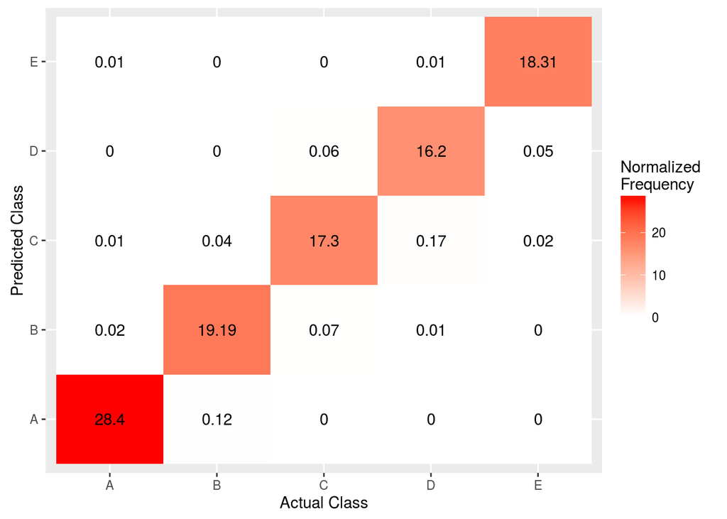

# Prediction

```r
data_pred       <- predict(model_rf, newdata=data_test)
data_pred
```

```
##  [1] B A B A A E D B A A B C B A E E A B B B
## Levels: A B C D E
```

```r
# confMat_test    <- confusionMatrix(data_test$classe, data_pred)
#
# p               <- ggplot(data.frame(confMat_test$table),
#                           aes(x=Reference, y=Prediction)
#                     )
# p               <- p + geom_tile(aes(fill=Freq))
# p               <- p + geom_text(aes(fill = Freq, label = round(Freq, 2)))
# p               <- p + scale_x_discrete(name = "Actual Class")
# p               <- p + scale_y_discrete(name = "Predicted Class")
# p               <- p + scale_fill_gradient(low = "white", high = "red")
# p               <- p + labs(fill="Normalized\nFrequency")
# p
```